# Transcription elongation regulator 1

## Figure 4: Best-cluster predicted contact maps over the two true folds.

Predicted contact maps (MSA-Transformer) for the clusters best matching each fold, over the true contacts of fold 1 (upper triangle) and fold 2 (lower). Divergent contacts between clusters are the contact-level signature of fold-switching.

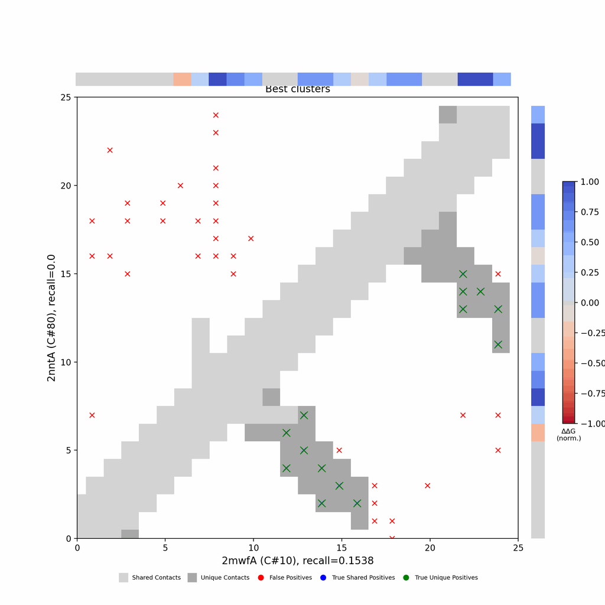

## Figure 5: Per-residue ΔΔG fold-preference contribution

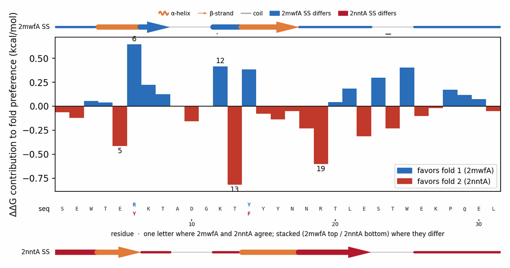

**More figures**

## Figure 6: Deep-MSA contact map panel / Best clusters contact map panel

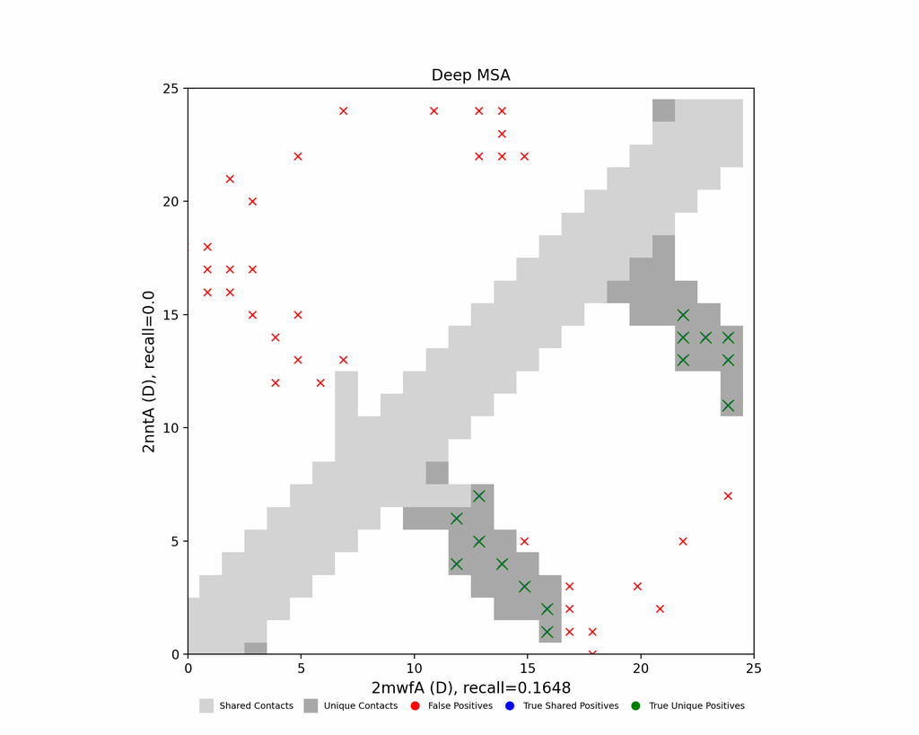

Deep-MSA contact map panel

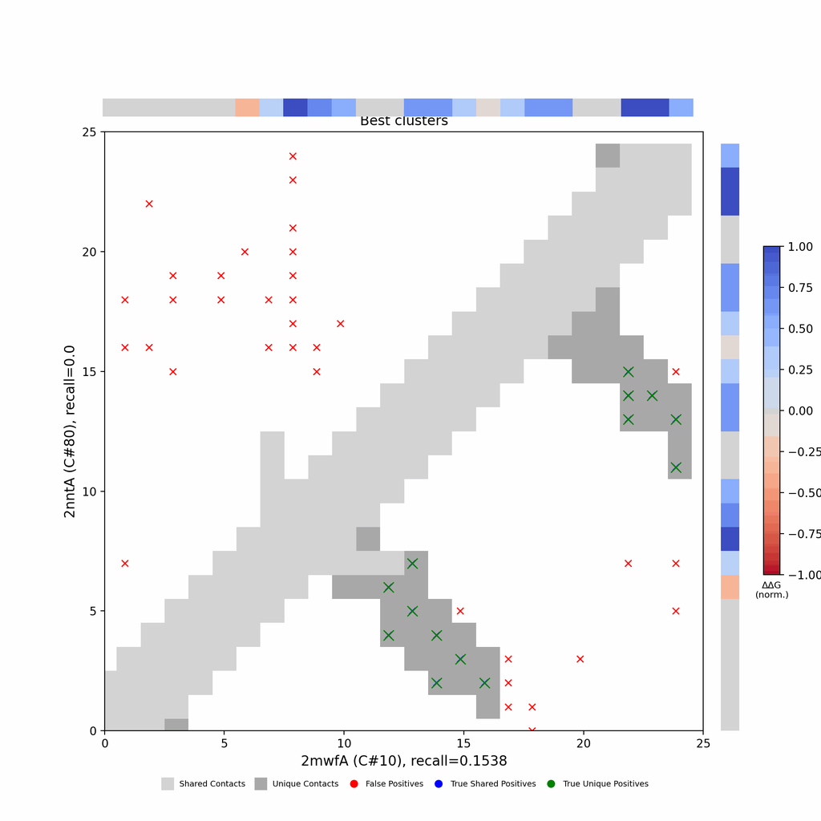

Best clusters contact map panel

## Figure 7: All clusters contact-map mosaic (small multiples).

[figure not shown]

## Figure 8: Phylo null: tree with shuffled cluster fold labels.

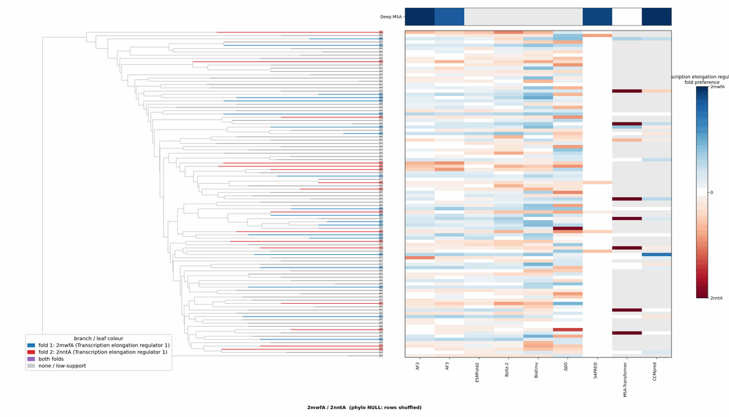

## Cluster metrics table

Per-cluster metrics underlying the figures above.

| cluster | n | neff | AF2_TM1 | AF2_TM2 | AF3_TM1 | AF3_TM2 | RE-MSAT-COM | RE-MSAT1 | RE-MSAT2 | ESM_SEQIDS | ESM_TM1 | ESM_TM2 | ΔΔG_Bias | ΔΔG_Bias_std | ΔΔG_frac_F1 | Boltz2_pref | S4PRED_pref | CCMpred_pref | BioEmu_pref |
| --- | --- | --- | --- | --- | --- | --- | --- | --- | --- | --- | --- | --- | --- | --- | --- | --- | --- | --- | --- |
| Deep | - | - | 0.59 | 0.2 | 0.54 | 0.21 | 0.13 | 0.49 | 0.09 | - | - | - | - | - | - | - | 0.11 | 0.22 | - |
| 000 | 5699.0 | 3677.0 | 0.56 | 0.19 | 0.55 | 0.17 | 0.0 | 0.0 | 0.0 | 004; 005; 004; 005; 001; 001; 003; 003; 002; 002 | 0.55 ± 0.02 | 0.21 ± 0.02 | 0.02 | 1.71 | 0.4 | 0.31 | 0.12 | 0.21 | 0.21 |
| 001 | 1179.0 | 825.0 | 0.43 | 0.24 | 0.46 | 0.22 | 0.14 | 0.2 | 0.06 | 004; 004; 003; 003; 001; 001; 002; 002; 008; 008 | 0.53 ± 0.04 | 0.22 ± 0.01 | -0.35 | 1.31 | 0.3 | 0.2 | 0.12 | 0.04 | 0.17 |
| 002 | 1102.0 | 852.0 | 0.51 | 0.19 | 0.44 | 0.19 | 0.0 | 0.0 | 0.0 | 001; 001; 003; 003; 002; 002; 007; 007; 004; 004 | 0.54 ± 0.03 | 0.21 ± 0.01 | 0.49 | 1.75 | 0.5 | 0.27 | 0.12 | 0.11 | 0.18 |
| 003 | 1032.0 | 809.0 | 0.5 | 0.18 | 0.49 | 0.18 | 0.11 | 0.15 | 0.05 | 002; 002; 003; 005; 005; 003; 001; 001; 009; 009 | 0.54 ± 0.04 | 0.23 ± 0.01 | 0.74 | 1.87 | 0.6 | 0.19 | 0.12 | 0.1 | 0.21 |
| 004 | 761.0 | 557.0 | 0.57 | 0.2 | 0.55 | 0.21 | 0.0 | 0.0 | 0.04 | 002; 004; 005; 005; 004; 002; 006; 006; 001; 001 | 0.53 ± 0.04 | 0.22 ± 0.03 | 0.52 | 2.26 | 0.6 | 0.32 | 0.12 | 0.05 | 0.22 |
| 005 | 749.0 | 276.0 | 0.51 | 0.19 | 0.55 | 0.19 | 0.0 | 0.0 | 0.0 | 001; 001; 002; 002; 005; 003; 003; 005; 006; 006 | 0.53 ± 0.02 | 0.20 ± 0.02 | -0.22 | 1.57 | 0.5 | 0.35 | 0.12 | 0.09 | 0.13 |
| 006 | 546.0 | 340.0 | 0.56 | 0.19 | 0.55 | 0.19 | 0.0 | 0.03 | 0.0 | 002; 002; 003; 003; 001; 001; 004; 004; 008; 008 | 0.54 ± 0.02 | 0.20 ± 0.01 | -0.79 | 2.75 | 0.3 | 0.29 | 0.12 | 0.07 | 0.17 |
| 007 | 418.0 | 178.0 | 0.5 | 0.19 | 0.5 | 0.21 | 0.0 | 0.0 | 0.0 | 006; 006; 003; 003; 002; 002; 001; 001; 005; 005 | 0.54 ± 0.03 | 0.21 ± 0.01 | 0.2 | 2.1 | 0.4 | 0.27 | 0.12 | 0.1 | 0.11 |
| 008 | 410.0 | 310.0 | 0.5 | 0.19 | 0.56 | 0.16 | 0.0 | 0.0 | 0.0 | 004; 004; 002; 003; 003; 002; 005; 005; 001; 001 | 0.55 ± 0.03 | 0.20 ± 0.02 | 0.62 | 2.63 | 0.6 | 0.31 | 0.12 | 0.06 | 0.21 |
| 009 | 395.0 | 270.0 | 0.46 | 0.19 | 0.51 | 0.18 | 0.0 | 0.04 | 0.0 | 001; 001; 004; 004; 003; 003; 005; 005; 008; 008 | 0.50 ± 0.01 | 0.20 ± 0.03 | -0.15 | 2.22 | 0.5 | 0.33 | 0.12 | 0.1 | 0.22 |
| 010 | 363.0 | 86.0 | 0.56 | 0.22 | 0.57 | 0.24 | 0.08 | 0.46 | 0.05 | 001; 001; 004; 004; 006; 006; 003; 005; 005; 003 | 0.53 ± 0.01 | 0.20 ± 0.02 | -0.19 | 1.71 | 0.6 | 0.3 | 0.12 | 0.05 | 0.09 |
| 011 | 333.0 | 194.0 | 0.57 | 0.2 | 0.56 | 0.19 | 0.0 | 0.0 | 0.0 | 001; 001; 003; 003; 004; 004; 005; 005; 008; 008 | 0.51 ± 0.02 | 0.21 ± 0.02 | -0.15 | 2.29 | 0.4 | 0.32 | 0.12 | 0.02 | 0.16 |
| 012 | 315.0 | 143.0 | 0.48 | 0.21 | 0.44 | 0.2 | 0.0 | 0.0 | 0.0 | 003; 003; 001; 001; 004; 004; 002; 002; 009; 010 | 0.52 ± 0.05 | 0.20 ± 0.02 | 0.22 | 1.76 | 0.5 | 0.29 | 0.12 | 0.0 | 0.16 |
| 013 | 314.0 | 217.0 | 0.35 | 0.28 | 0.41 | 0.2 | 0.0 | 0.0 | 0.0 | 005; 005; 001; 004; 001; 004; 003; 003; 002; 002 | 0.54 ± 0.02 | 0.21 ± 0.01 | 0.08 | 2.25 | 0.5 | 0.24 | 0.12 | 0.07 | 0.13 |
| 014 | 309.0 | 255.0 | 0.49 | 0.2 | 0.57 | 0.19 | 0.0 | 0.0 | 0.0 | 001; 001; 002; 002; 003; 003; 005; 005; 008; 010 | 0.55 ± 0.04 | 0.21 ± 0.01 | -0.27 | 2.94 | 0.5 | 0.29 | 0.12 | 0.05 | 0.2 |
| 015 | 303.0 | 131.0 | 0.46 | 0.21 | 0.47 | 0.21 | 0.0 | 0.0 | 0.05 | 001; 001; 003; 003; 004; 004; 002; 002; 006; 005 | 0.54 ± 0.02 | 0.20 ± 0.02 | -0.4 | 2.64 | 0.3 | 0.24 | 0.12 | 0.09 | 0.15 |
| 016 | 290.0 | 69.0 | 0.45 | 0.21 | 0.46 | 0.24 | 0.0 | 0.0 | 0.0 | 001; 001; 004; 004; 003; 003; 005; 005; 002; 006 | 0.51 ± 0.04 | 0.21 ± 0.02 | -0.49 | 2.57 | 0.4 | 0.22 | 0.12 | 0.04 | 0.1 |
| 017 | 289.0 | 234.0 | 0.51 | 0.22 | 0.47 | 0.2 | 0.0 | 0.0 | 0.0 | 003; 003; 001; 001; 002; 002; 008; 008; 009; 009 | 0.53 ± 0.04 | 0.20 ± 0.01 | 0.19 | 2.27 | 0.5 | 0.26 | 0.12 | 0.02 | 0.23 |
| 018 | 288.0 | 236.0 | 0.44 | 0.19 | 0.44 | 0.23 | 0.0 | 0.03 | 0.05 | 003; 003; 006; 006; 005; 005; 001; 004; 001; 004 | 0.54 ± 0.02 | 0.21 ± 0.01 | -0.05 | 1.63 | 0.6 | 0.21 | 0.12 | 0.05 | 0.17 |
| 019 | 266.0 | 103.0 | 0.57 | 0.22 | 0.54 | 0.2 | 0.0 | 0.0 | 0.05 | 003; 003; 005; 005; 001; 001; 002; 002; 010; 010 | 0.54 ± 0.05 | 0.21 ± 0.01 | -0.71 | 2.15 | 0.5 | 0.37 | 0.12 | 0.02 | 0.17 |
| 020 | 254.0 | 186.0 | 0.51 | 0.19 | 0.52 | 0.2 | 0.0 | 0.0 | 0.04 | 004; 004; 005; 005; 006; 006; 001; 001; 003; 003 | 0.53 ± 0.02 | 0.20 ± 0.01 | 0.21 | 1.76 | 0.7 | 0.29 | 0.12 | 0.04 | 0.23 |
| 021 | 254.0 | 155.0 | 0.44 | 0.17 | 0.44 | 0.18 | 0.0 | 0.0 | 0.0 | - | - | - | -0.08 | 2.77 | 0.6 | 0.24 | 0.12 | - | 0.1 |
| 022 | 253.0 | 189.0 | 0.48 | 0.2 | 0.39 | 0.22 | 0.13 | 0.24 | 0.06 | - | - | - | 0.13 | 2.14 | 0.5 | 0.25 | 0.12 | - | 0.22 |
| 023 | 251.0 | 196.0 | 0.48 | 0.19 | 0.51 | 0.19 | 0.0 | 0.0 | 0.0 | - | - | - | 0.03 | 2.41 | 0.5 | 0.24 | 0.12 | - | 0.16 |
| 024 | 247.0 | 155.0 | 0.42 | 0.2 | 0.42 | 0.2 | 0.0 | 0.0 | 0.05 | - | - | - | 0.16 | 2.68 | 0.6 | 0.21 | 0.12 | - | 0.1 |
| 025 | 244.0 | 220.0 | 0.53 | 0.2 | 0.47 | 0.2 | 0.0 | 0.0 | 0.04 | - | - | - | -0.06 | 2.31 | 0.6 | 0.32 | 0.12 | - | 0.22 |
| 026 | 242.0 | 171.0 | 0.49 | 0.19 | 0.47 | 0.18 | 0.0 | 0.0 | 0.0 | - | - | - | 0.03 | 2.28 | 0.6 | 0.27 | 0.12 | - | 0.17 |
| 027 | 235.0 | 107.0 | 0.39 | 0.19 | 0.42 | 0.2 | 0.0 | 0.0 | 0.0 | - | - | - | -0.68 | 2.08 | 0.4 | 0.23 | 0.12 | - | 0.04 |
| 028 | 232.0 | 99.0 | 0.46 | 0.2 | 0.43 | 0.2 | 0.0 | 0.0 | 0.05 | - | - | - | 0.05 | 2.06 | 0.4 | 0.25 | 0.12 | - | 0.15 |

[output cut: 71 more lines]